# Making graphics for the paper and supplementary information

Erik Ø. Sørensen

08 februar, 2021

# Reading data

Reading data from Ipsos:

```r
wavedate_df <- tribble(~Wavemarker, ~wavedt,
                       4, "2020-3-18",  # Not to be used - No COVID-19 reminder
                       5, "2020-3-24",
                       6, "2020-3-25",
                       7, "2020-3-26",
                       8, "2020-3-27",
                       9, "2020-3-30",
                       10,"2020-3-31",
                       11,"2020-4-1",
                       12,"2020-4-2") %>%
  mutate(wavedt = as.Date(wavedt))

ipsos <- haven::read_dta(here::here("data","processed", "ipsos_mmnyt_processed_release.dta")) %>%
 mutate( year=2020,
         country="United States",
         state = as.character(haven::as_factor(State_Recoded)),
         solidarity = 10 - prior_self_over_soc,
         zsolidarity = weighted.scale(solidarity, Weightvar, na.rm=TRUE),
         nationalism = prior_national_over_global,
         znationalism = weighted.scale(prior_national_over_global, Weightvar, na.rm = TRUE),
         zluck_unfair = weighted.scale(luck_unfair_agree, Weightvar, na.rm = TRUE),
         redistribution = gov_reduce_inequality_agree,
         zredistribution = weighted.scale(redistribution, Weightvar, na.rm = TRUE),
         politics = as.character(haven::as_factor(GDW6)),
         republican = as.numeric(ifelse(politics!="Prefer not to answer",
                                         politics=="Republican",
                                         NA)),
         female = as.numeric(resp_gender==2),
         ) %>% left_join(wavedate_df) %>%
  filter(!is.na(wavedt)) %>%
  filter(!is.na(corona_prime))
```

Merging in the confirmed cases by state.

```r
confirmed <- read.csv(here::here("data","corona_status_March-28.csv")) %>%
  mutate(confirmed_cases = confirmed/pop2019 * 100000000) %>%
  select(state, confirmed_cases)
ipsos <- ipsos %>% left_join(confirmed, by="state")
```

I create a new variable splitting the states by whether they have above or below (population-weighted) median exposure to the virus by the in-state number of confirmed cases.

```r
ipsos <- ipsos %>% mutate( high_confirmed =
                             as.numeric(confirmed_cases > wtd.quantile(confirmed_cases,
                                                                       0.5,
                                                                       weight = Weightvar)))
wtd.quantile(ipsos$confirmed_cases, 0.5, weight=ipsos$Weightvar
             )
```

```
##      50%
## 16458.03
```

# Descriptive statistics:

## Unconditional, numerical summary

```r
ipsos %>% summarize( mean_solidarity = weighted.mean(solidarity, Weightvar, na.rm=TRUE),
                  se_solidarity = weighted.se(solidarity, Weightvar, na.rm=TRUE),
                  sd_solidarity = weighted.sd(solidarity, Weightvar, na.rm=TRUE),
                  mean_nationalism = weighted.mean(nationalism, Weightvar, na.rm=TRUE),
                  se_nationalism = weighted.se(nationalism, Weightvar, na.rm=TRUE),
                  sd_nationalism = weighted.sd(nationalism, Weightvar, na.rm=TRUE),
                  mean_luckunfair = weighted.mean(luck_unfair_agree, Weightvar, na.rm=TRUE),
                  se_luckunfair = weighted.se(luck_unfair_agree, Weightvar, na.rm=TRUE),
                  sd_luckunfair = weighted.sd(luck_unfair_agree, Weightvar, na.rm=TRUE),
                  mean_redistribution = weighted.mean(redistribution, Weightvar, na.rm=TRUE),
                  se_redistribution = weighted.se(redistribution, Weightvar, na.rm=TRUE),
                  sd_redistribution = weighted.sd(redistribution, Weightvar, na.rm=TRUE),
                  mean_universalhealthcare = weighted.mean(fed_univ_healthcare, Weightvar, na.rm=TRUE),
                  se_universalhealthcare = weighted.se(fed_univ_healthcare, Weightvar, na.rm=TRUE),
                  sd_universalhealthcare = weighted.sd(fed_univ_healthcare, Weightvar, na.rm=TRUE)
) %>% pivot_longer(mean_solidarity:sd_universalhealthcare, values_to = 'estimate') %>%
  separate("name",sep = "_", into=c("statistic","outcome")) %>%
  pivot_wider(id_cols="outcome",names_from="statistic",values_from="estimate") %>%
  mutate(outcome = factor(outcome, levels = c("solidarity","nationalism","luckunfair",
                                              "redistribution", "universalhealthcare"))) %>%
  arrange(outcome) %>% knitr::kable(digits=3)
```

| outcome | mean | se | sd |
| --- | --- | --- | --- |
| solidarity | 3.565 | 0.028 | 2.323 |
| nationalism | 7.062 | 0.029 | 2.383 |
| luckunfair | 3.659 | 0.014 | 1.118 |
| redistribution | 2.363 | 0.009 | 0.776 |
| universalhealthcare | 0.627 | 0.006 | 0.484 |

## Broken down by treatment and control:

```r
ipsos %>% filter(!is.na(corona_prime)) %>%
  group_by(corona_prime) %>%
  summarize( mean_solidarity = weighted.mean(solidarity, Weightvar, na.rm=TRUE),
             se_solidarity = weighted.se(solidarity, Weightvar, na.rm=TRUE),
             sd_solidarity = weighted.sd(solidarity, Weightvar, na.rm=TRUE),
             mean_nationalism = weighted.mean(nationalism, Weightvar, na.rm=TRUE),
             se_nationalism = weighted.se(nationalism, Weightvar, na.rm=TRUE),
             sd_nationalism = weighted.sd(nationalism, Weightvar, na.rm=TRUE),
             mean_luckunfair = weighted.mean(luck_unfair_agree, Weightvar, na.rm=TRUE),
             se_luckunfair = weighted.se(luck_unfair_agree, Weightvar, na.rm=TRUE),
             sd_luckunfair = weighted.sd(luck_unfair_agree, Weightvar, na.rm=TRUE),
             mean_redistribution = weighted.mean(redistribution, Weightvar, na.rm=TRUE),
             se_redistribution = weighted.se(redistribution, Weightvar, na.rm=TRUE),
             sd_redistribution = weighted.sd(redistribution, Weightvar, na.rm=TRUE),
             mean_universalhealthcare = weighted.mean(fed_univ_healthcare, Weightvar, na.rm=TRUE),
             se_universalhealthcare = weighted.se(fed_univ_healthcare, Weightvar, na.rm=TRUE),
             sd_universalhealthcare = weighted.sd(fed_univ_healthcare, Weightvar, na.rm=TRUE)
  ) %>% pivot_longer(mean_solidarity:sd_universalhealthcare, values_to = 'estimate') %>%
  separate("name",sep = "_", into=c("statistic","outcome")) %>%
  pivot_wider(id_cols=c("corona_prime", "outcome"), names_from="statistic", values_from="estimate") %>%
  mutate(outcome = factor(outcome, levels = c("solidarity","nationalism","luckunfair",
                                              "redistribution", "universalhealthcare"))) %>%
  arrange(corona_prime, outcome) %>% knitr::kable(digits=3)
```

| corona_prime | outcome | mean | se | sd |
| --- | --- | --- | --- | --- |
| 0 | solidarity | 3.484 | 0.040 | 2.312 |
| 0 | nationalism | 7.042 | 0.041 | 2.378 |
| 0 | luckunfair | 3.707 | 0.020 | 1.136 |
| 0 | redistribution | 2.361 | 0.013 | 0.781 |
| 0 | universalhealthcare | 0.631 | 0.008 | 0.483 |
| 1 | solidarity | 3.648 | 0.040 | 2.330 |
| 1 | nationalism | 7.082 | 0.041 | 2.388 |
| 1 | luckunfair | 3.611 | 0.019 | 1.097 |
| 1 | redistribution | 2.365 | 0.013 | 0.771 |
| 1 | universalhealthcare | 0.623 | 0.008 | 0.485 |

## Key histograms

```r
solidarity_hist_df <- ipsos %>%
  summarise(weighted.bars(solidarity, Weightvar, values=0:10, na.rm=TRUE))
solidarity_hist_df %>% knitr::kable(digits=3)
```

| v | proportion |
| --- | --- |
| 0 | 0.147 |
| 1 | 0.052 |
| 2 | 0.129 |
| 3 | 0.155 |
| 4 | 0.125 |
| 5 | 0.251 |
| 6 | 0.051 |
| 7 | 0.042 |
| 8 | 0.021 |
| 9 | 0.008 |
| 10 | 0.020 |

```r
solidarity_hist <- solidarity_hist_df  %>%
  ggplot(aes(x=v, y=proportion)) +
  geom_bar(stat='identity') +
  theme_minimal() +
  scale_x_continuous(breaks=0:10) +
  labs(x=element_blank(),
       y="Proportion",
       title="Solidarity")
compassion_hist_df <- ipsos %>%
  summarise(weighted.bars(compassion_agree, Weightvar, na.rm=TRUE))
compassion_hist_df %>% knitr::kable(digits=3)
```

| v | proportion |
| --- | --- |
| 1 | 0.012 |
| 2 | 0.042 |
| 3 | 0.173 |
| 4 | 0.442 |
| 5 | 0.332 |

```r
compassion_hist <- compassion_hist_df  %>%
  ggplot(aes(x=v, y=proportion)) +
  geom_bar(stat='identity') +
  theme_minimal() +
  scale_x_continuous(breaks=1:5) +
  labs(x=element_blank(),
       y="Proportion",
       title="Compassion")
```

Support for nationalism and “no borders”

```r
nationalism_hist_df <- ipsos %>%
  summarise(weighted.bars(nationalism, Weightvar, values=0:10, na.rm=TRUE))
nationalism_hist_df %>% knitr::kable(digits=3)
```

| v | proportion |
| --- | --- |
| 0 | 0.021 |
| 1 | 0.006 |
| 2 | 0.017 |
| 3 | 0.026 |
| 4 | 0.039 |
| 5 | 0.172 |
| 6 | 0.101 |
| 7 | 0.154 |
| 8 | 0.157 |
| 9 | 0.088 |
| 10 | 0.220 |

```r
nationalism_hist <- nationalism_hist_df %>%
  ggplot(aes(x=v, y=proportion)) +
  geom_bar(stat='identity') +
  theme_minimal() +
  scale_x_continuous(breaks=0:10) +
  labs(x=element_blank(),
       y="Proportion",
       title="Nationalism")
borders_hist_df <- ipsos %>%
  summarize(weighted.bars(noborders_agree, Weightvar, na.rm=TRUE))
borders_hist_df %>% knitr::kable(digits=3)
```

| v | proportion |
| --- | --- |
| 1 | 0.259 |
| 2 | 0.202 |
| 3 | 0.237 |
| 4 | 0.185 |
| 5 | 0.117 |

```r
borders_hist <- borders_hist_df %>%
  ggplot(aes(x=v, y=proportion)) +
  geom_bar(stat='identity') +
  theme_minimal() +
  scale_x_continuous(breaks=1:5) +
  labs(x=element_blank(),
       y="Proportion",
       title="No borders")
```

```r
luckunfair_hist_df <- ipsos %>%
  summarise(weighted.bars(luck_unfair_agree, Weightvar, na.rm=TRUE))
luckunfair_hist_df %>% knitr::kable(digits=3)
```

| v | proportion |
| --- | --- |
| 1 | 0.047 |
| 2 | 0.096 |
| 3 | 0.285 |
| 4 | 0.296 |
| 5 | 0.276 |

```r
luckunfair_hist <- luckunfair_hist_df %>%
  ggplot(aes(x=v, y=proportion)) +
  geom_bar(stat='identity') +
  theme_minimal() +
  labs(x=element_blank(),
       y="Proportion",
       title="Luck unfair")
luckdetermine_hist_df <- ipsos %>%
  summarise(weighted.bars(luck_determ_agree, Weightvar, na.rm=TRUE))
luckdetermine_hist_df %>% knitr::kable(digits=3)
```

| v | proportion |
| --- | --- |
| 1 | 0.160 |
| 2 | 0.227 |
| 3 | 0.273 |
| 4 | 0.261 |
| 5 | 0.078 |

```r
luckdetermine_hist <- luckdetermine_hist_df %>%
  ggplot(aes(x=v, y=proportion)) +
  geom_bar(stat='identity') +
  theme_minimal() +
  labs(x=element_blank(),
       y="Proportion",
       title="Luck belief")
```

```r
redistribution_hist_df <- ipsos %>%
  summarise(weighted.bars(redistribution, Weightvar, na.rm=TRUE)) %>%
  mutate( vf = fct_recode( factor(v),
          "Generally disagree" = "1",
          "Neutral" = "2",
          "Generally agree"="3"))

redistribution_hist_df %>% knitr::kable(digits=3)
```

| v | proportion | vf |
| --- | --- | --- |
| 1 | 0.186 | Generally disagree |
| 2 | 0.266 | Neutral |
| 3 | 0.548 | Generally agree |

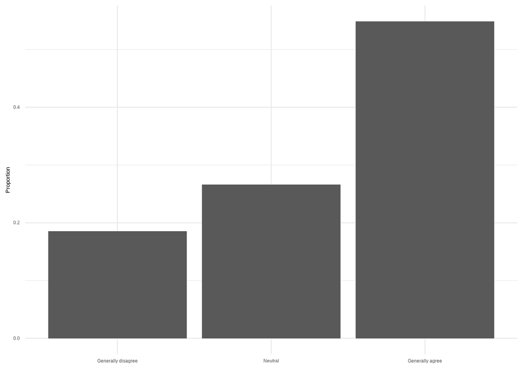

```r
redistribution_hist <- redistribution_hist_df %>%
  ggplot(aes(x=vf, y=proportion)) +
  geom_bar(stat='identity') +
  theme_minimal() +
  labs(x=element_blank(),
       y="Proportion")
redistribution_hist
```

```r
ggsave(here::here("graphs", "redistribution.pdf"), widt = 16, height = 10, units = "cm")
```

Putting the graphs together

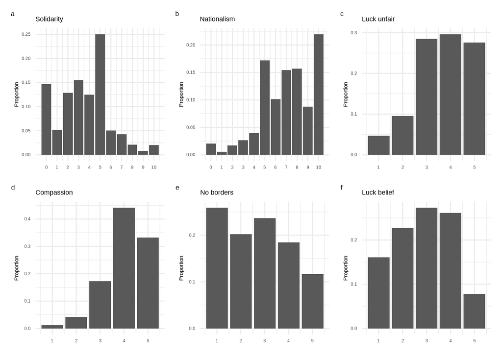

```r
outcomes_hist <- solidarity_hist + nationalism_hist + luckunfair_hist +
  compassion_hist + borders_hist + luckdetermine_hist +
  plot_annotation(tag_levels = 'a')
outcomes_hist
```

```r
ggsave(here::here("graphs","outcomes_hist.pdf"), width=16, height=10, units="cm")
```

## Proportions split by treatment

For **solidarity**:

```r
ipsos %>% group_by(corona_prime) %>%
  summarise(weighted.bars(solidarity, Weightvar, values=0:10, na.rm=TRUE)) %>%
  pivot_wider(id_cols=v, names_from = corona_prime, values_from = proportion) %>%
  arrange(v) %>% knitr::kable(digits=3)
```

| v | 0 | 1 |
| --- | --- | --- |
| 0 | 0.153 | 0.141 |
| 1 | 0.055 | 0.049 |
| 2 | 0.135 | 0.122 |
| 3 | 0.153 | 0.156 |
| 4 | 0.127 | 0.122 |
| 5 | 0.242 | 0.259 |
| 6 | 0.050 | 0.051 |
| 7 | 0.037 | 0.048 |
| 8 | 0.023 | 0.019 |
| 9 | 0.005 | 0.010 |
| 10 | 0.019 | 0.021 |

For **nationalism**:

```r
ipsos %>% group_by(corona_prime) %>%
  summarise(weighted.bars(nationalism, Weightvar, na.rm=TRUE)) %>%
  pivot_wider(id_cols=v, names_from = corona_prime, values_from = proportion) %>%
  arrange(v) %>% knitr::kable(digits=3)
```

| v | 0 | 1 |
| --- | --- | --- |
| 0 | 0.020 | 0.021 |
| 1 | 0.005 | 0.006 |
| 2 | 0.017 | 0.017 |
| 3 | 0.030 | 0.023 |
| 4 | 0.042 | 0.036 |
| 5 | 0.165 | 0.178 |
| 6 | 0.104 | 0.098 |
| 7 | 0.158 | 0.150 |
| 8 | 0.155 | 0.159 |
| 9 | 0.088 | 0.088 |
| 10 | 0.216 | 0.224 |

For **luck unfair**:

```r
ipsos %>% group_by(corona_prime) %>%
  summarise(weighted.bars(luck_unfair_agree, Weightvar, na.rm=TRUE)) %>%
  pivot_wider(id_cols=v, names_from = corona_prime, values_from = proportion) %>%
  arrange(v) %>% knitr::kable(digits=3)
```

| v | 0 | 1 |
| --- | --- | --- |
| 1 | 0.048 | 0.046 |
| 2 | 0.100 | 0.092 |
| 3 | 0.250 | 0.320 |
| 4 | 0.303 | 0.289 |
| 5 | 0.299 | 0.253 |

For **redistribution**:

```r
ipsos %>% group_by(corona_prime) %>%
  summarise(weighted.bars(redistribution, Weightvar, na.rm=TRUE)) %>%
  pivot_wider(id_cols=v, names_from = corona_prime, values_from = proportion) %>%
  arrange(v) %>% knitr::kable(digits=3)
```

| v | 0 | 1 |
| --- | --- | --- |
| 1 | 0.190 | 0.181 |
| 2 | 0.259 | 0.273 |
| 3 | 0.551 | 0.546 |

# Collecting estimates on moral landscape

I want to collect estimates in a dataset which is clear about

- outcome (solidarity, unfair_luck, nationalism). String.
- treatment_grouped (which group are we looking at heterogeneity with respect to). String.
- within_group_type (male/female ; low/high ; …) String.
- estimate (numerical)
- Standard error (numerical)

I can use `treatment_grouped` to put color on the bars, and within `within_group_type` to add annotations.

## Main treatment effects

```r
s_m <- ipsos %>% lm(zsolidarity ~ corona_prime + retirement_age + female + highinc + republican + higheduc +
                     child + alone + urban + high_confirmed +
                     northeast + midwest + south, data=., weights=Weightvar)
l_m <- ipsos %>% lm(zluck_unfair ~ corona_prime + retirement_age + female + highinc +
                    republican + higheduc +
                     child + alone + urban + high_confirmed +
                     northeast + midwest + south, data=., weights=Weightvar)
n_m <- ipsos %>% lm(znationalism ~ corona_prime + retirement_age + female +
                                highinc + republican + higheduc +
                     child + alone + urban + high_confirmed +
                     northeast + midwest + south, data=., weights=Weightvar)
m_df <- tibble(outcome = c("solidarity","luck_unfair","nationalism"),
               treatment_grouped = c("Average","Average", "Average"),
               within_group_typed = c("","",""),
               estimate = c( coef(s_m)[['corona_prime']], coef(l_m)[['corona_prime']],
                             coef(n_m)[['corona_prime']]),
               se = c( sqrt(diag(vcovHC(s_m, type = "HC1")))[['corona_prime']],
                       sqrt(diag(vcovHC(l_m, type = "HC1")))[['corona_prime']],
                       sqrt(diag(vcovHC(n_m, type = "HC1")))[['corona_prime']]))
m_df
```

```
## # A tibble: 3 x 5
##   outcome     treatment_grouped within_group_typed estimate     se
##   <chr>       <chr>             <chr>                 <dbl>  <dbl>
## 1 solidarity  Average           ""                  0.0645  0.0252
## 2 luck_unfair Average           ""                 -0.0835  0.0255
## 3 nationalism Average           ""                  0.00579 0.0244
```

## Heterogeneity by retirement age

```r
ipsos <- ipsos %>% mutate(ret_prime = corona_prime * retirement_age,
                          nret_prime = corona_prime * (1-retirement_age))
s_ret <- ipsos %>% lm(zsolidarity ~ ret_prime + nret_prime +
                      retirement_age  + female + highinc + republican + higheduc +
                     child + alone + urban + high_confirmed +
                     northeast + midwest + south, data=., weights=Weightvar)
l_ret <- ipsos %>% lm(zluck_unfair ~ ret_prime + nret_prime +
                      retirement_age  + female + highinc + republican + higheduc +
                     child + alone + urban + high_confirmed +
                     northeast + midwest + south, data=., weights=Weightvar)
n_ret <- ipsos %>% lm(znationalism ~ ret_prime + nret_prime +
                      retirement_age  + female + highinc + republican + higheduc +
                     child + alone + urban + high_confirmed +
                     northeast + midwest + south, data=., weights=Weightvar)
ret_df <- tibble(outcome = c("solidarity", "solidarity", "luck_unfair", "luck_unfair",
                             "nationalism", "nationalism"),
                 treatment_grouped = "Retirement age",
                 within_group_typed = c("below","reached", "below","reached", "below","reached"),
                 estimate = c(coef(s_ret)[['nret_prime']],
                              coef(s_ret)[['ret_prime']],
                              coef(l_ret)[['nret_prime']],
                              coef(l_ret)[['ret_prime']],
                              coef(n_ret)[['nret_prime']],
                              coef(n_ret)[['ret_prime']]),
                 se = c(sqrt(diag(vcovHC(s_ret, type = "HC1")))[['nret_prime']],
                        sqrt(diag(vcovHC(s_ret, type = "HC1")))[['ret_prime']],
                        sqrt(diag(vcovHC(l_ret, type = "HC1")))[['nret_prime']],
                        sqrt(diag(vcovHC(l_ret, type = "HC1")))[['ret_prime']],
                        sqrt(diag(vcovHC(n_ret, type = "HC1")))[['nret_prime']],
                        sqrt(diag(vcovHC(n_ret, type = "HC1")))[['ret_prime']]))
ret_df
```

```
## # A tibble: 6 x 5
##   outcome     treatment_grouped within_group_typed estimate     se
##   <chr>       <chr>             <chr>                 <dbl>  <dbl>
## 1 solidarity  Retirement age    below                0.0475 0.0283
## 2 solidarity  Retirement age    reached              0.144  0.0542
## 3 luck_unfair Retirement age    below               -0.0776 0.0286
## 4 luck_unfair Retirement age    reached             -0.111  0.0554
## 5 nationalism Retirement age    below                0.0226 0.0277
## 6 nationalism Retirement age    reached             -0.0727 0.0488
```

## Heterogeneity by gender

```r
ipsos <- ipsos %>% mutate(female_prime = corona_prime * female,
                          nfemale_prime = corona_prime * (1-female))
s_sex <- ipsos %>% lm(zsolidarity ~ female_prime + nfemale_prime +
                      retirement_age + female + highinc + republican + higheduc +
                     child + alone + urban + high_confirmed +
                     northeast + midwest + south, data=., weights=Weightvar)
l_sex <- ipsos %>% lm(zluck_unfair ~ female_prime + nfemale_prime +
                      retirement_age + female + highinc + republican + higheduc +
                     child + alone + urban + high_confirmed +
                     northeast + midwest + south, data=., weights=Weightvar)
n_sex <- ipsos %>% lm(znationalism ~ female_prime + nfemale_prime +
                      retirement_age + female + highinc + republican + higheduc +
                     child + alone + urban + high_confirmed +
                     northeast + midwest + south, data=., weights=Weightvar)
sex_df <- tibble(outcome = c("solidarity", "solidarity", "luck_unfair", "luck_unfair",
                             "nationalism", "nationalism"),
                 treatment_grouped = "Gender",
                 within_group_typed = c("male","female", "male","female", "male","female"),
                 estimate = c(coef(s_sex)[['nfemale_prime']],
                              coef(s_sex)[['female_prime']],
                              coef(l_sex)[['nfemale_prime']],
                              coef(l_sex)[['female_prime']],
                              coef(n_sex)[['nfemale_prime']],
                              coef(n_sex)[['female_prime']]),
                 se = c(sqrt(diag(vcovHC(s_sex, type = "HC1")))[['nfemale_prime']],
                        sqrt(diag(vcovHC(s_sex, type = "HC1")))[['female_prime']],
                        sqrt(diag(vcovHC(l_sex, type = "HC1")))[['nfemale_prime']],
                        sqrt(diag(vcovHC(l_sex, type = "HC1")))[['female_prime']],
                        sqrt(diag(vcovHC(n_sex, type = "HC1")))[['nfemale_prime']],
                        sqrt(diag(vcovHC(n_sex, type = "HC1")))[['female_prime']]))
sex_df
```

```
## # A tibble: 6 x 5
##   outcome     treatment_grouped within_group_typed  estimate     se
##   <chr>       <chr>             <chr>                  <dbl>  <dbl>
## 1 solidarity  Gender            male                0.0634   0.0369
## 2 solidarity  Gender            female              0.0656   0.0343
## 3 luck_unfair Gender            male               -0.0668   0.0382
## 4 luck_unfair Gender            female             -0.0996   0.0340
## 5 nationalism Gender            male               -0.000129 0.0365
## 6 nationalism Gender            female              0.0115   0.0326
```

# Heterogeneity by Income

```r
ipsos <- ipsos %>% mutate(hinc_prime = corona_prime * highinc,
                          linc_prime = corona_prime * (1-highinc))
s_inc <- ipsos %>% lm(zsolidarity ~ hinc_prime + linc_prime +
                      retirement_age + female + highinc + republican + higheduc +
                     child + alone + urban + high_confirmed +
                     northeast + midwest + south, data=., weights=Weightvar)
l_inc <- ipsos %>% lm(zluck_unfair ~ hinc_prime + linc_prime +
                      retirement_age + female + highinc + republican + higheduc +
                     child + alone + urban + high_confirmed +
                     northeast + midwest + south, data=., weights=Weightvar)
n_inc <- ipsos %>% lm(znationalism ~ hinc_prime + linc_prime +
                      retirement_age + female + highinc + republican + higheduc +
                     child + alone + urban + high_confirmed +
                     northeast + midwest + south, data=., weights=Weightvar)
inc_df <- tibble(outcome = c("solidarity", "solidarity", "luck_unfair", "luck_unfair",
                             "nationalism", "nationalism"),
                 treatment_grouped = "Income",
                 within_group_typed = c("low","high", "low","high", "low","high"),
                 estimate = c(coef(s_inc)[['linc_prime']],
                              coef(s_inc)[['hinc_prime']],
                              coef(l_inc)[['linc_prime']],
                              coef(l_inc)[['hinc_prime']],
                              coef(n_inc)[['linc_prime']],
                              coef(n_inc)[['hinc_prime']]),
                 se = c(sqrt(diag(vcovHC(s_inc, type = "HC1")))[['linc_prime']],
                        sqrt(diag(vcovHC(s_inc, type = "HC1")))[['hinc_prime']],
                        sqrt(diag(vcovHC(l_inc, type = "HC1")))[['linc_prime']],
                        sqrt(diag(vcovHC(l_inc, type = "HC1")))[['hinc_prime']],
                        sqrt(diag(vcovHC(n_inc, type = "HC1")))[['linc_prime']],
                        sqrt(diag(vcovHC(n_inc, type = "HC1")))[['hinc_prime']]))
inc_df
```

```
## # A tibble: 6 x 5
##   outcome     treatment_grouped within_group_typed estimate     se
##   <chr>       <chr>             <chr>                 <dbl>  <dbl>
## 1 solidarity  Income            low                 0.0374  0.0343
## 2 solidarity  Income            high                0.0924  0.0368
## 3 luck_unfair Income            low                -0.0415  0.0325
## 4 luck_unfair Income            high               -0.127   0.0395
## 5 nationalism Income            low                -0.00176 0.0336
## 6 nationalism Income            high                0.0136  0.0354
```

# Heterogeneity by Education

```r
ipsos <- ipsos %>% mutate(hedu_prime = corona_prime * higheduc,
                          ledu_prime = corona_prime * (1-higheduc))
s_edu <- ipsos %>% lm(zsolidarity ~ ledu_prime + hedu_prime +
                      retirement_age + female + highinc + republican + higheduc +
                     child + alone + urban + high_confirmed +
                     northeast + midwest + south, data=., weights=Weightvar)
l_edu <- ipsos %>% lm(zluck_unfair ~ ledu_prime + hedu_prime +
                      retirement_age + female + highinc + republican + higheduc +
                     child + alone + urban + high_confirmed +
                     northeast + midwest + south, data=., weights=Weightvar)
n_edu <- ipsos %>% lm(znationalism ~  ledu_prime + hedu_prime +
                      retirement_age + female + highinc + republican + higheduc +
                     child + alone + urban + high_confirmed +
                     northeast + midwest + south, data=., weights=Weightvar)
edu_df <- tibble(outcome = c("solidarity", "solidarity", "luck_unfair", "luck_unfair",
                             "nationalism", "nationalism"),
                 treatment_grouped = "Education",
                 within_group_typed = c("low","high", "low","high", "low","high"),
                 estimate = c(coef(s_edu)[['ledu_prime']],
                              coef(s_edu)[['hedu_prime']],
                              coef(l_edu)[['ledu_prime']],
                              coef(l_edu)[['hedu_prime']],
                              coef(n_edu)[['ledu_prime']],
                              coef(n_edu)[['hedu_prime']]),
                 se = c(sqrt(diag(vcovHC(s_edu, type = "HC1")))[['ledu_prime']],
                        sqrt(diag(vcovHC(s_edu, type = "HC1")))[['hedu_prime']],
                        sqrt(diag(vcovHC(l_edu, type = "HC1")))[['ledu_prime']],
                        sqrt(diag(vcovHC(l_edu, type = "HC1")))[['hedu_prime']],
                        sqrt(diag(vcovHC(n_edu, type = "HC1")))[['ledu_prime']],
                        sqrt(diag(vcovHC(n_edu, type = "HC1")))[['hedu_prime']]))
edu_df
```

```
## # A tibble: 6 x 5
##   outcome     treatment_grouped within_group_typed estimate     se
##   <chr>       <chr>             <chr>                 <dbl>  <dbl>
## 1 solidarity  Education         low                  0.0926 0.0349
## 2 solidarity  Education         high                 0.0328 0.0362
## 3 luck_unfair Education         low                 -0.0457 0.0344
## 4 luck_unfair Education         high                -0.126  0.0380
## 5 nationalism Education         low                 -0.0205 0.0342
## 6 nationalism Education         high                 0.0356 0.0348
```

# Heterogeneity by politics

```r
ipsos <- ipsos %>% mutate(rep_prime = corona_prime * republican,
                          nrep_prime = corona_prime * (1-republican))
s_pol <- ipsos %>% lm(zsolidarity ~ rep_prime + nrep_prime +
                      retirement_age + female + highinc + republican + higheduc +
                     child + alone + urban + high_confirmed +
                     northeast + midwest + south, data=., weights=Weightvar)
l_pol <- ipsos %>% lm(zluck_unfair ~ rep_prime + nrep_prime +
                      retirement_age + female + highinc + republican + higheduc +
                     child + alone + urban + high_confirmed +
                     northeast + midwest + south, data=., weights=Weightvar)
n_pol <- ipsos %>% lm(znationalism ~  rep_prime + nrep_prime +
                      retirement_age + female + highinc + republican + higheduc +
                     child + alone + urban + high_confirmed +
                     northeast + midwest + south, data=., weights=Weightvar)
pol_df <- tibble(outcome = c("solidarity", "solidarity", "luck_unfair", "luck_unfair",
                             "nationalism", "nationalism"),
                 treatment_grouped = "Political",
                 within_group_typed = c("Republican","Non-Republican", "Republican","Non-Republican",
                                        "Republican","Non-Republican"),
                 estimate = c(coef(s_pol)[['rep_prime']],
                              coef(s_pol)[['nrep_prime']],
                              coef(l_pol)[['rep_prime']],
                              coef(l_pol)[['nrep_prime']],
                              coef(n_pol)[['rep_prime']],
                              coef(n_pol)[['nrep_prime']]),
                 se = c(sqrt(diag(vcovHC(s_pol, type = "HC1")))[['rep_prime']],
                        sqrt(diag(vcovHC(s_pol, type = "HC1")))[['nrep_prime']],
                        sqrt(diag(vcovHC(l_pol, type = "HC1")))[['rep_prime']],
                        sqrt(diag(vcovHC(l_pol, type = "HC1")))[['nrep_prime']],
                        sqrt(diag(vcovHC(n_pol, type = "HC1")))[['rep_prime']],
                        sqrt(diag(vcovHC(n_pol, type = "HC1")))[['nrep_prime']]))
pol_df
```

```
## # A tibble: 6 x 5
##   outcome     treatment_grouped within_group_typed estimate     se
##   <chr>       <chr>             <chr>                 <dbl>  <dbl>
## 1 solidarity  Political         Republican          0.0827  0.0386
## 2 solidarity  Political         Non-Republican      0.0528  0.0331
## 3 luck_unfair Political         Republican         -0.00987 0.0418
## 4 luck_unfair Political         Non-Republican     -0.131   0.0322
## 5 nationalism Political         Republican         -0.0330  0.0342
## 6 nationalism Political         Non-Republican      0.0308  0.0335
```

## Heterogeneity by number of confirmed cases

I do this by two groups, since we want to think about there being different treatment effects in the two groups.

```r
ipsos <- ipsos %>% mutate(hconf_prime = corona_prime * high_confirmed,
                          lconf_prime = corona_prime * (1-high_confirmed))
s_con <- ipsos %>% lm(zsolidarity ~ lconf_prime + hconf_prime  +
                      retirement_age + female + highinc + republican + higheduc +
                     child + alone + urban + high_confirmed +
                     northeast + midwest + south, data=., weights=Weightvar)
l_con <- ipsos %>% lm(zluck_unfair ~ lconf_prime + hconf_prime +
                      retirement_age + female + highinc + republican + higheduc +
                     child + alone + urban + high_confirmed +
                     northeast + midwest + south, data=., weights=Weightvar)
n_con <- ipsos %>% lm(znationalism ~  lconf_prime + hconf_prime +
                      retirement_age + female + highinc + republican + higheduc +
                     child + alone + urban + high_confirmed +
                     northeast + midwest + south, data=., weights=Weightvar)
con_df <- tibble(outcome = c("solidarity", "solidarity", "luck_unfair", "luck_unfair",
                             "nationalism", "nationalism"),
                 treatment_grouped = "Confirmed cases",
                 within_group_typed = c("low","high", "low","high","low","high"),
                 estimate = c(coef(s_con)[['lconf_prime']],
                              coef(s_con)[['hconf_prime']],
                              coef(l_con)[['lconf_prime']],
                              coef(l_con)[['hconf_prime']],
                              coef(n_con)[['lconf_prime']],
                              coef(n_con)[['hconf_prime']]),
                 se = c(sqrt(diag(vcovHC(s_con, type = "HC1")))[['lconf_prime']],
                        sqrt(diag(vcovHC(s_con, type = "HC1")))[['hconf_prime']],
                        sqrt(diag(vcovHC(l_con, type = "HC1")))[['lconf_prime']],
                        sqrt(diag(vcovHC(l_con, type = "HC1")))[['hconf_prime']],
                        sqrt(diag(vcovHC(n_con, type = "HC1")))[['lconf_prime']],
                        sqrt(diag(vcovHC(n_con, type = "HC1")))[['hconf_prime']]))
con_df
```

```
## # A tibble: 6 x 5
##   outcome     treatment_grouped within_group_typed estimate     se
##   <chr>       <chr>             <chr>                 <dbl>  <dbl>
## 1 solidarity  Confirmed cases   low                 0.0842  0.0357
## 2 solidarity  Confirmed cases   high                0.0454  0.0355
## 3 luck_unfair Confirmed cases   low                -0.0912  0.0367
## 4 luck_unfair Confirmed cases   high               -0.0761  0.0354
## 5 nationalism Confirmed cases   low                -0.00393 0.0347
## 6 nationalism Confirmed cases   high                0.0152  0.0344
```

## Putting all the estimates together

```r
dfs <- list(m_df, ret_df, sex_df, inc_df, edu_df, pol_df, con_df)
all_estimates <- reduce(dfs, bind_rows)
with(all_estimates, table(treatment_grouped))
```

```
## treatment_grouped
##         Average Confirmed cases       Education          Gender          Income
##               3               6               6               6               6
##       Political  Retirement age
##               6               6
```

```r
all_estimates_levels <- c("Average", "Political", "Income","Education", "Gender","Retirement age","Confirmed cases")
all_estimates <- all_estimates %>% mutate(treatment_grouped = factor(treatment_grouped, levels=all_estimates_levels))
all_estimates
```

```
## # A tibble: 39 x 5
##    outcome     treatment_grouped within_group_typed estimate     se
##    <chr>       <fct>             <chr>                 <dbl>  <dbl>
##  1 solidarity  Average           ""                  0.0645  0.0252
##  2 luck_unfair Average           ""                 -0.0835  0.0255
##  3 nationalism Average           ""                  0.00579 0.0244
##  4 solidarity  Retirement age    "below"             0.0475  0.0283
##  5 solidarity  Retirement age    "reached"           0.144   0.0542
##  6 luck_unfair Retirement age    "below"            -0.0776  0.0286
##  7 luck_unfair Retirement age    "reached"          -0.111   0.0554
##  8 nationalism Retirement age    "below"             0.0226  0.0277
##  9 nationalism Retirement age    "reached"          -0.0727  0.0488
## 10 solidarity  Gender            "male"              0.0634  0.0369
## # … with 29 more rows
```

## Graph of treatment effects

Solidarity

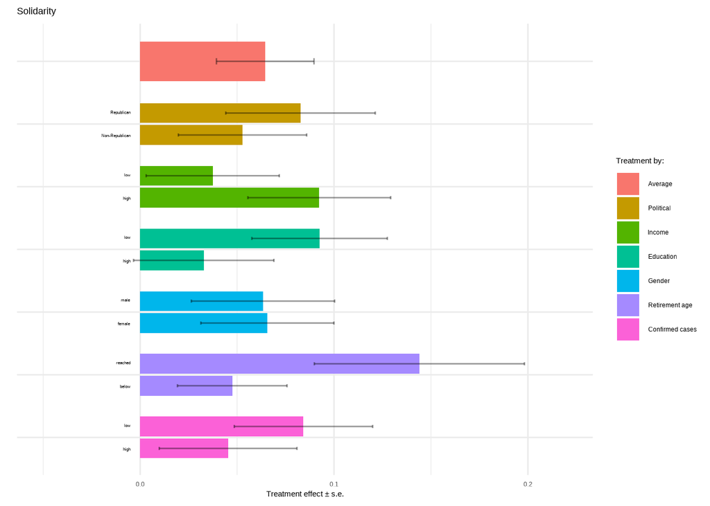

```r
gdf <- all_estimates %>% filter(outcome=="solidarity")
gsol <- gdf %>% ggplot(aes(x=as.factor( treatment_grouped),
             y=estimate, fill=treatment_grouped, group=within_group_typed)) +
  geom_bar(stat='identity',position=position_dodge2(width=0.7), width=0.7) +
  geom_errorbar(aes(ymin=estimate-se, ymax=estimate+se),
                position=position_dodge(width=0.7),
                width=0.1, alpha=0.4) +
  theme_minimal() +
  scale_x_discrete(labels=element_blank(),
                   limits = rev(all_estimates_levels)) +
  scale_y_continuous(limits=c(-0.05,0.22)) +
  labs(y = "Treatment effect \u00B1 s.e.", x=element_blank(),
       title ="Solidarity", fill="Treatment by:") +
  geom_text(position = position_dodge(width=0.75),  size=2,
            aes( y=-0.005, label=within_group_typed, hjust=1), angle=0) + coord_flip()
gsol
```

Luck unfair

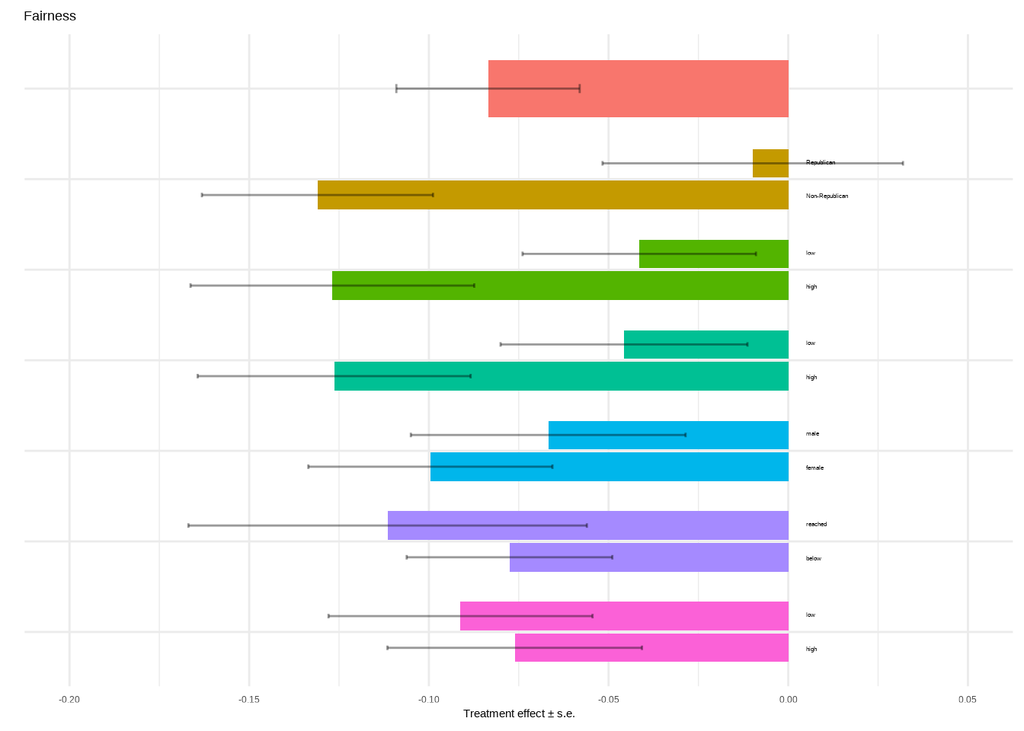

```r
glunfair <- all_estimates %>% filter(outcome=="luck_unfair") %>%
  ggplot(aes(x=treatment_grouped,
             y=estimate, fill=treatment_grouped, group=within_group_typed)) +
  geom_bar(stat='identity',position=position_dodge2(width=0.7), width=0.7) +
  geom_errorbar(aes(ymin=estimate-se, ymax=estimate+se),
                position=position_dodge(width=0.7),
                width=0.1, alpha=0.4) +
  theme_minimal() +
  theme(legend.position = "none") +
  scale_x_discrete(labels=element_blank(),
                   limits = rev(all_estimates_levels)) +
  scale_y_continuous(limits=c(-0.20,0.05)) +
  labs(y = "Treatment effect \u00B1 s.e.", x=element_blank(),
       title ="Fairness", fill="Treatment by:") +
  geom_text(position = position_dodge(width=0.75), size=2,
            aes( y=0.005, label=within_group_typed, hjust=0), angle=0) + coord_flip()
glunfair
```

Nationalism

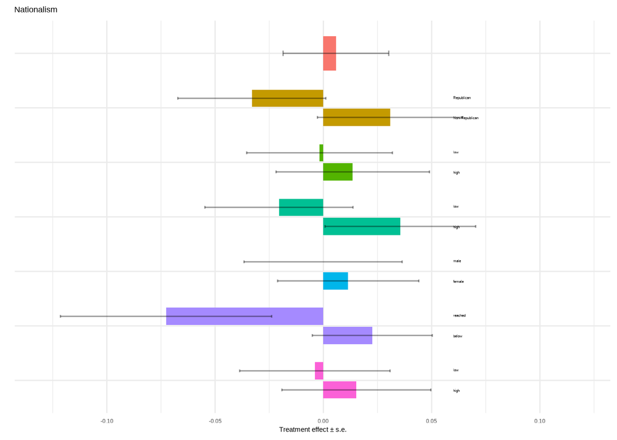

```r
gnat <- all_estimates %>% filter(outcome=="nationalism") %>%
  ggplot(aes(x=treatment_grouped,
             y=estimate, fill=treatment_grouped, group=within_group_typed)) +
  geom_bar(stat='identity',position=position_dodge2(width=0.7), width=0.7) +
  geom_errorbar(aes(ymin=estimate-se, ymax=estimate+se),
                position=position_dodge(width=0.7),
                width=0.1, alpha=0.4) +
  theme_minimal() +
  theme(legend.position = "none") +
  scale_x_discrete(labels=element_blank(),
                   limits = rev(all_estimates_levels)) +
  scale_y_continuous(limits=c(-0.13,0.12)) +
  labs(y = "Treatment effect \u00B1 s.e.", x=element_blank(),
       title ="Nationalism", fill="Treatment by:") +
  geom_text(position = position_dodge(width=0.75), size=2,
            aes( y=0.06, label=within_group_typed, hjust=0), angle=0) + coord_flip()
gnat
```

Putting them all together. This looks bad in the knitr-pdf, but ok with the larger graph saved to disk.

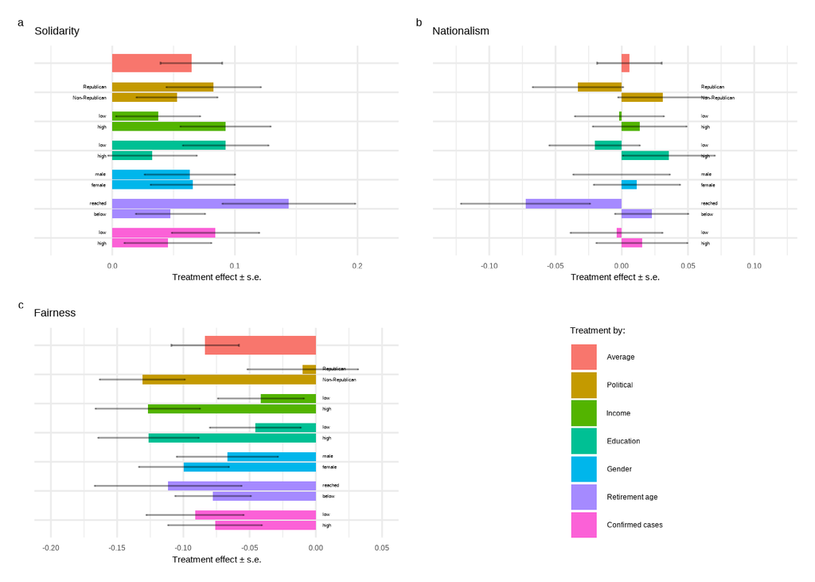

```r
tgraphs <- gsol + gnat + glunfair +  plot_layout(ncol=2, guides = 'collect') + guide_area() +
  plot_annotation(tag_levels = 'a')
tgraphs
```

```r
ggsave(here::here("graphs","treatment_effects.pdf"), width=17.8, height=11, units="cm")
```

# Treatment effects on policy preferences

I aim for the same file structure as for the moral landscape variables.

## The main treatment effects

```r
r_m <- ipsos %>% lm(zredistribution ~ corona_prime + retirement_age + female + highinc +
                      republican + higheduc + child + alone + urban + high_confirmed +
                      northeast + midwest + south, data=., weights=Weightvar)
h_m <- ipsos %>% lm(fed_univ_healthcare ~ corona_prime + retirement_age + female + highinc +
                      republican + higheduc + child + alone + urban + high_confirmed +
                      northeast + midwest + south, data=., weights=Weightvar)
mp_df <- tibble(outcome = c("redistribution","healthcare"),
                treatment_grouped = c("Average","Average"),
                within_group_typed = c("",""),
                estimate = c( coef(r_m)[['corona_prime']],
                              coef(h_m)[['corona_prime']]),
                se = c( sqrt(diag(vcov(r_m)))[['corona_prime']],
                        sqrt(diag(vcov(h_m)))[['corona_prime']]))
mp_df
```

```
## # A tibble: 2 x 5
##   outcome        treatment_grouped within_group_typed  estimate      se
##   <chr>          <chr>             <chr>                  <dbl>   <dbl>
## 1 redistribution Average           ""                  0.0140   0.0210
## 2 healthcare     Average           ""                 -0.000699 0.00975
```

## Heterogeneity by politics

```r
r_pol <- ipsos %>% lm(zredistribution ~  rep_prime + nrep_prime +
                        retirement_age + female + highinc +
                        republican + higheduc + child + alone + urban + high_confirmed +
                        northeast + midwest + south, data=., weights=Weightvar)
h_pol <- ipsos %>% lm(fed_univ_healthcare ~  rep_prime + nrep_prime +
                        retirement_age + female + highinc +
                        republican + higheduc + child + alone + urban + high_confirmed +
                        northeast + midwest + south, data=., weights=Weightvar)

polp_df <- tibble(outcome = c("redistribution", "redistribution", "healthcare", "healthcare"),
                 treatment_grouped = "Political",
                 within_group_typed = c("Republican","Non-Republican", "Republican","Non-Republican"),
                 estimate = c(coef(r_pol)[['rep_prime']],
                              coef(r_pol)[['nrep_prime']],
                              coef(h_pol)[['rep_prime']],
                              coef(h_pol)[['nrep_prime']]),
                 se = c(sqrt(diag(vcov(r_pol)))[['rep_prime']],
                        sqrt(diag(vcov(r_pol)))[['nrep_prime']],
                        sqrt(diag(vcov(h_pol)))[['rep_prime']],
                        sqrt(diag(vcov(h_pol)))[['nrep_prime']]))
polp_df
```

```
## # A tibble: 4 x 5
##   outcome        treatment_grouped within_group_typed  estimate     se
##   <chr>          <chr>             <chr>                  <dbl>  <dbl>
## 1 redistribution Political         Republican          0.0852   0.0335
## 2 redistribution Political         Non-Republican     -0.0318   0.0269
## 3 healthcare     Political         Republican         -0.000604 0.0156
## 4 healthcare     Political         Non-Republican     -0.000760 0.0125
```

## Putting all the estimates together

```r
dfpol <- reduce( list(mp_df, polp_df), bind_rows)
dfpol
```

```
## # A tibble: 6 x 5
##   outcome        treatment_grouped within_group_typed  estimate      se
##   <chr>          <chr>             <chr>                  <dbl>   <dbl>
## 1 redistribution Average           ""                  0.0140   0.0210
## 2 healthcare     Average           ""                 -0.000699 0.00975
## 3 redistribution Political         "Republican"        0.0852   0.0335
## 4 redistribution Political         "Non-Republican"   -0.0318   0.0269
## 5 healthcare     Political         "Republican"       -0.000604 0.0156
## 6 healthcare     Political         "Non-Republican"   -0.000760 0.0125
```

## Making the graphs and putting them together

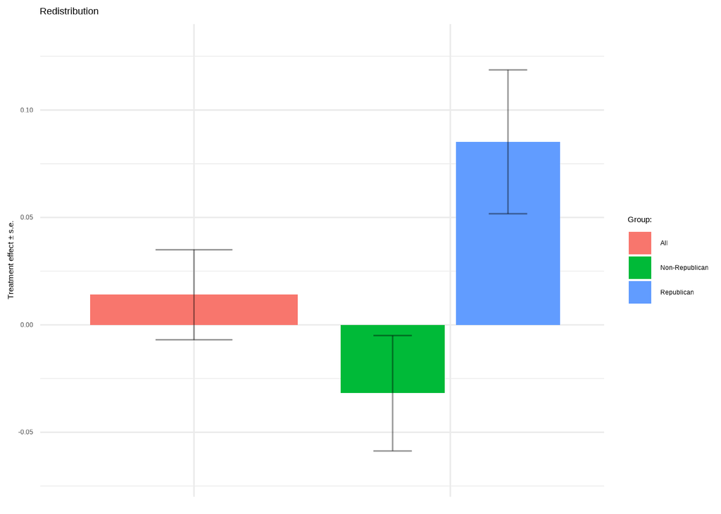

```r
dist_pol <- dfpol %>% filter(outcome=="redistribution") %>%
  mutate(within_group_typed = ifelse(treatment_grouped=="Average","All", within_group_typed )) %>%
  ggplot(aes(x=treatment_grouped,
             y=estimate, fill=within_group_typed, group=within_group_typed)) +
  geom_bar(stat='identity',position=position_dodge2(width=0.1)) +
  geom_errorbar(aes(ymin=estimate-se, ymax=estimate+se),
                position=position_dodge(width=0.9),
                width=0.3, alpha=0.4) +
  theme_minimal() +
  scale_x_discrete(labels=element_blank()) +
  labs(y = "Treatment effect \u00B1 s.e.", x=element_blank(),
       title ="Redistribution", fill="Group:") +
  scale_y_continuous(lim = c(-0.07, 0.13))
dist_pol
```

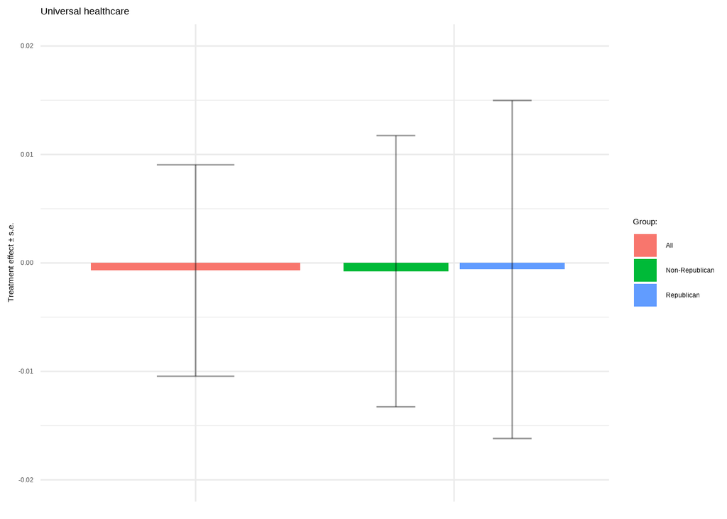

```r
healthcare_pol <- dfpol %>% filter(outcome=="healthcare") %>%
  mutate(within_group_typed = ifelse(treatment_grouped=="Average","All", within_group_typed )) %>%
  ggplot(aes(x=treatment_grouped,
             y=estimate, fill=within_group_typed, group=within_group_typed)) +
  geom_bar(stat='identity',position=position_dodge2(width=0.1)) +
  geom_errorbar(aes(ymin=estimate-se, ymax=estimate+se),
                position=position_dodge(width=0.9),
                width=0.3, alpha=0.4) +
  theme_minimal() +
  scale_x_discrete(labels=element_blank()) +
  labs(y = "Treatment effect \u00B1 s.e.", x=element_blank(),
       title ="Universal healthcare", fill="Group:") +
  scale_y_continuous(lim = c(-0.02, 0.02))
healthcare_pol
```

# Relating policy to moral landscape

First, creating the dataset of state means

```r
outcome_means <- ipsos %>%
  group_by(state) %>%
  summarize(
    mean_zsolidarity = weighted.mean(zsolidarity, weight, na.rm=TRUE),
    mean_zluckunfair = weighted.mean(zluck_unfair, weight, na.rm=TRUE),
    mean_zredistribution = weighted.mean(zredistribution, weight, na.rm=TRUE),
    mean_znationalism = weighted.mean(znationalism, weight, na.rm = TRUE),
    mean_universalhealthcare = weighted.mean(fed_univ_healthcare, weight, na.rm=TRUE),
    n = sum(Weightvar)
  )
```

## First panel relates redistribution to solidarity

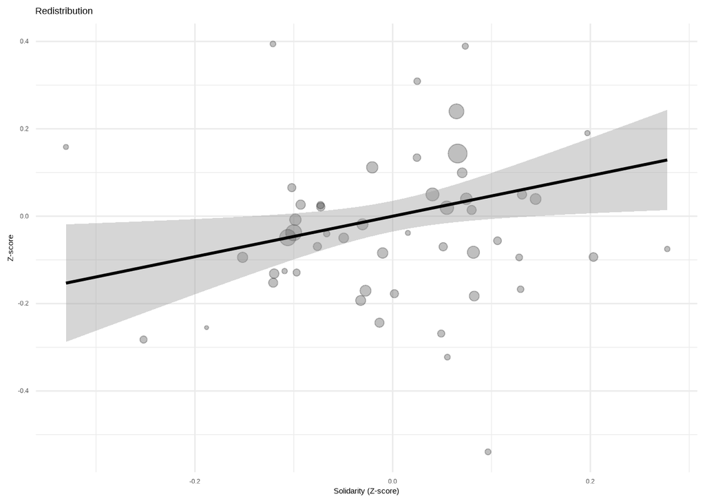

```r
gSR <- outcome_means %>% ggplot(aes(y=mean_zredistribution, x=mean_zsolidarity, weight=n)) +
  geom_point(aes(size=n), alpha=0.25) +
  geom_smooth(method='lm', color="black", linetype="solid") +
  theme_minimal() +
  theme(legend.position = 'none') +
  labs(x = "Solidarity (Z-score)",
       y = "Z-score",
       title ="Redistribution")
gSR
```

## Second panel

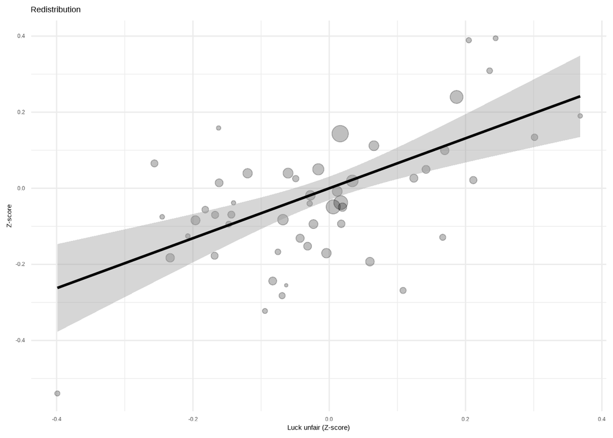

```r
gLR <- outcome_means %>% ggplot(aes(y=mean_zredistribution, x=mean_zluckunfair, weight=n)) +
  geom_point(aes(size=n), alpha=0.25) +
  geom_smooth(method='lm', color="black", linetype="solid") +
  theme_minimal() +
  theme(legend.position = 'none') +
  labs(x = "Luck unfair (Z-score)",
       y = "Z-score",
       title ="Redistribution")
gLR
```

## Third panel relates health care to solidarity

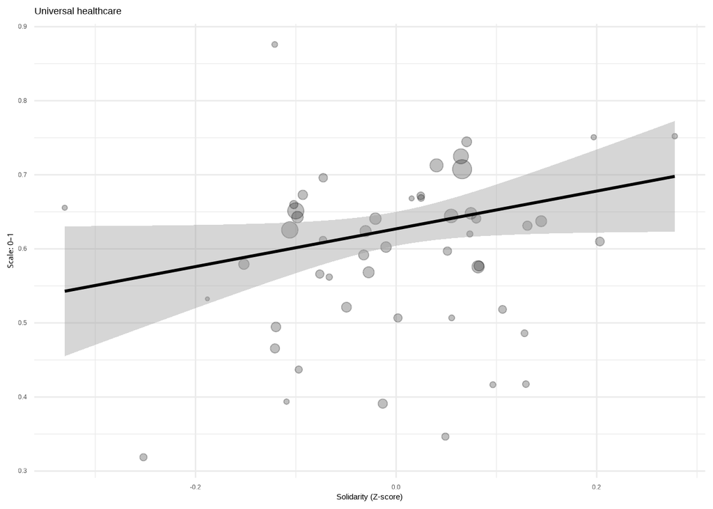

```r
gSH <- outcome_means %>% ggplot(aes(y=mean_universalhealthcare, x=mean_zsolidarity, weight=n)) +
  geom_point(aes(size=n), alpha=0.25) +
  geom_smooth(method='lm', color="black", linetype="solid") +
  theme_minimal() +
  theme(legend.position = 'none') +
  labs(x = "Solidarity (Z-score)",
       y = "Scale: 0\u20131",
       title ="Universal healthcare")
gSH
```

## Fourth panel relates health care support to luck unfair

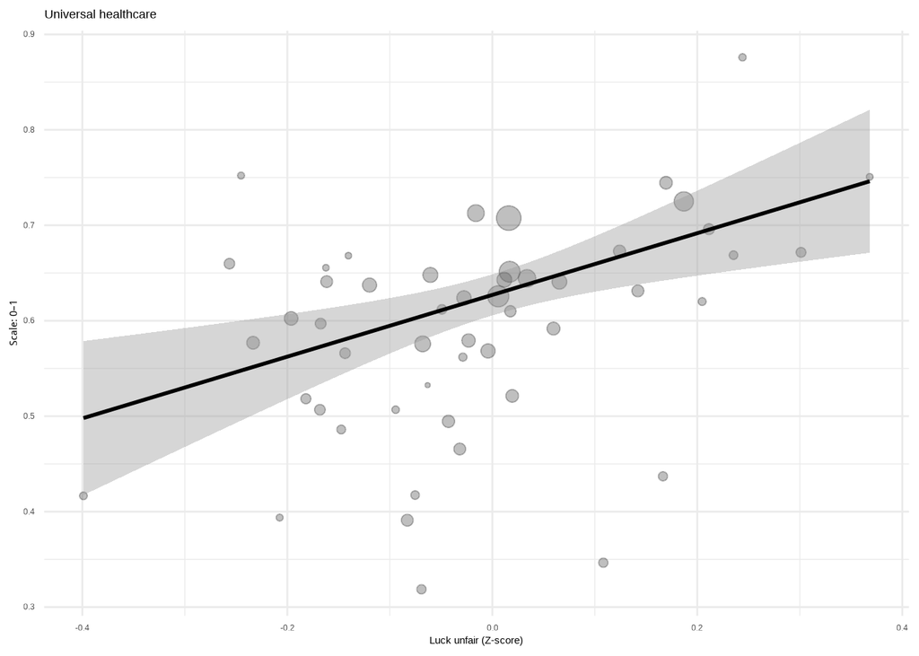

```r
gIH <- outcome_means %>% ggplot(aes(y=mean_universalhealthcare, x=mean_zluckunfair, weight=n)) +
  geom_point(aes(size=n), alpha=0.25) +
  geom_smooth(method='lm', color="black", linetype="solid") +
  theme_minimal() +
  theme(legend.position = 'none') +
  labs(x = "Luck unfair (Z-score)",
       y = "Scale: 0\u20131",
       title = "Universal healthcare")
gIH
```

# Remixes

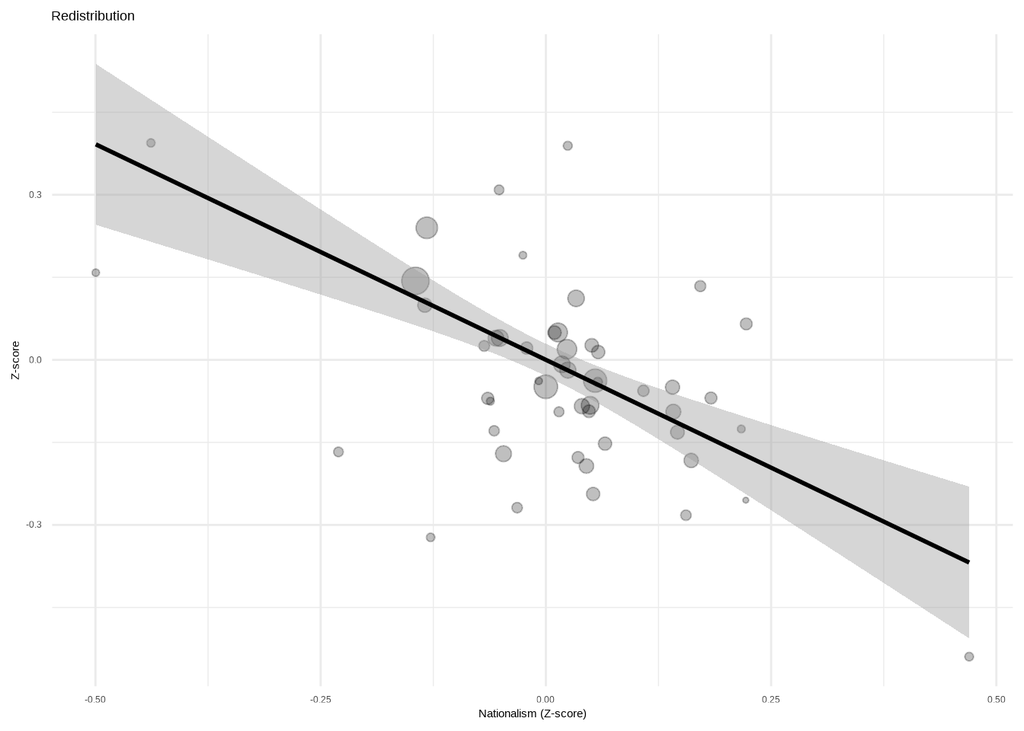

```r
gNR <- outcome_means %>% ggplot(aes(y=mean_zredistribution, x=mean_znationalism, weight=n)) +
  geom_point(aes(size=n), alpha=0.25) +
  geom_smooth(method='lm', color="black", linetype="solid") +
  theme_minimal() +
  theme(legend.position = 'none') +
  labs(x = "Nationalism (Z-score)",
       y = "Z-score",
       title ="Redistribution")
gNR
```

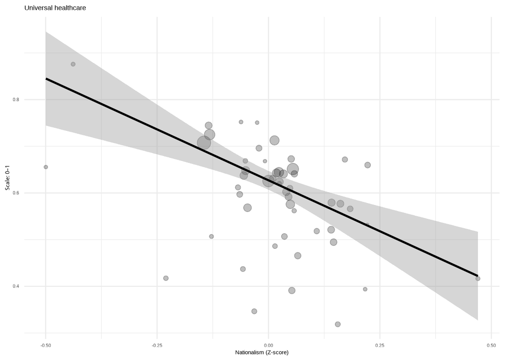

```r
gNH <- outcome_means %>% ggplot(aes(y=mean_universalhealthcare, x=mean_znationalism, weight=n)) +
  geom_point(aes(size=n), alpha=0.25) +
  geom_smooth(method='lm', color="black", linetype="solid") +
  theme_minimal() +
  theme(legend.position = 'none') +
  labs(x = "Nationalism (Z-score)",
       y = "Scale: 0\u20131",
       title ="Universal healthcare")
gNH
```

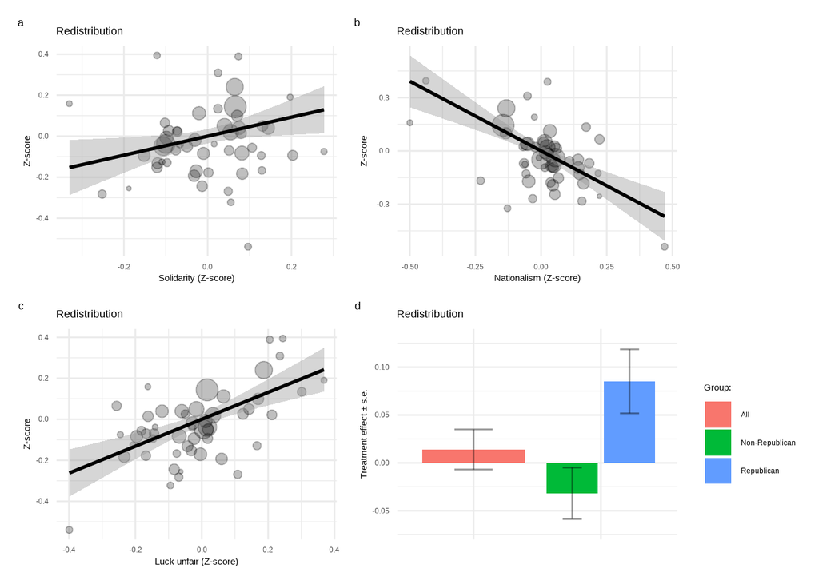

```r
remix_redist <- gSR + gNR + gLR +  dist_pol + plot_annotation(tag_levels = 'a')
remix_redist
```

```r
ggsave(here::here("graphs","remix_redist.pdf"), width=16, height=10, units="cm")
```

The same remix figure for the Supplementary materials, with health cares as outcome.

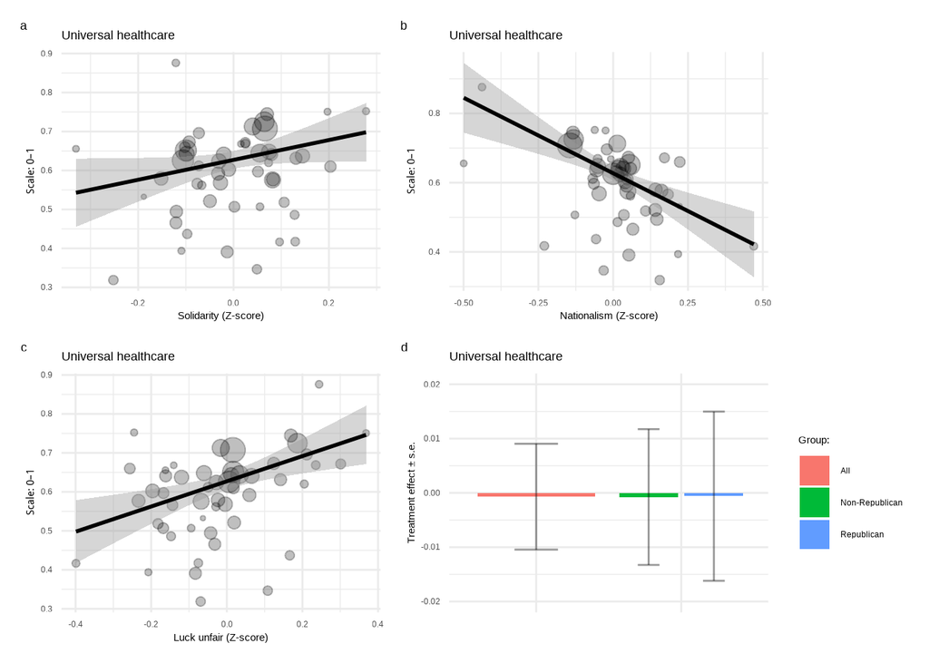

```r
remix_redist_health <- gSH + gNH + gIH +  healthcare_pol + plot_annotation(tag_levels = 'a')
remix_redist_health
```

```r
ggsave(here::here("graphs","remix_health.pdf"), width=16, height=10, units="cm")
```

# Moral and political landscape

We want to show treatment effects on moral landscape.

```r
political_df <- ipsos %>% filter(!is.na(corona_prime)) %>%
  filter(!is.na(republican)) %>%
  group_by(republican, corona_prime) %>%
  summarize( mean_zsolidarity = weighted.mean(zsolidarity, Weightvar, na.rm=TRUE),
             mean_zluckunfair = weighted.mean(zluck_unfair, Weightvar, na.rm=TRUE),
             se_zsolidarity = weighted.se(zsolidarity, Weightvar, na.rm=TRUE),
             se_zluckunfair = weighted.se(zluck_unfair, Weightvar, na.rm=TRUE))
overall_df <- ipsos %>%  filter(!is.na(corona_prime)) %>%
  group_by(corona_prime) %>%
  summarize( mean_zsolidarity = weighted.mean(zsolidarity, Weightvar, na.rm=TRUE),
             mean_zluckunfair = weighted.mean(zluck_unfair, Weightvar, na.rm=TRUE),
             se_zsolidarity = weighted.se(zsolidarity, Weightvar, na.rm=TRUE),
             se_zluckunfair = weighted.se(zluck_unfair, Weightvar, na.rm=TRUE))
joined_df <- political_df %>% bind_rows(overall_df) %>%
  ungroup() %>%
  mutate(grph_group = ifelse(!is.na(republican), 2+republican, 1),
         polgr = factor(grph_group, labels=c("Average", "Non-Republican", "Republican")),
         prime = factor(corona_prime, labels=c("Control", "COVID-19 reminded")))
```

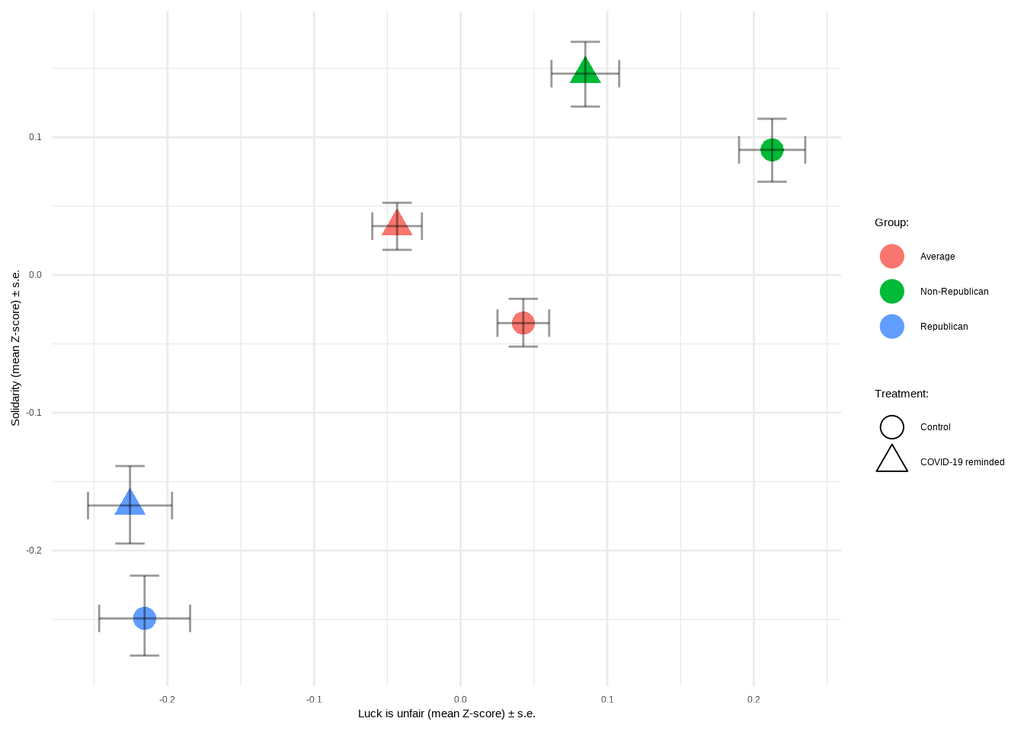

```r
landscape_graph <- joined_df %>% ggplot(aes(x=mean_zluckunfair, y=mean_zsolidarity,
                                            color=polgr, shape=prime,
                                            ymin = mean_zsolidarity - se_zsolidarity,
                                            ymax = mean_zsolidarity + se_zluckunfair,
                                            xmin = mean_zluckunfair - se_zluckunfair,
                                            xmax = mean_zluckunfair + se_zluckunfair)) +
  geom_point(size=5) +
  geom_errorbar(orientation = "x", width=0.02, color="black", alpha=0.4) +
  geom_errorbar(orientation = "y", width=0.02, color="black", alpha=0.4) +
  theme_minimal() +
  labs( x = "Luck is unfair (mean Z-score) \u00B1 s.e.",
        y = "Solidarity (mean Z-score) \u00B1 s.e.",
        color = "Group:",
        shape = "Treatment:") +
  guides(color = guide_legend(order=1),
         shape = guide_legend(order=2)) +
  guides(shape = guide_legend(override.aes = list(shape = c(1,2))))
landscape_graph
```

```r
ggsave(here::here("graphs","landscape_graph.pdf"), width=16, height=10, units="cm")
```

# Revision: What about distribution of outcomes?

Reviewer 1 is interested in distributional effects:

> Is it possible to also conduct tests on the distribution of stated preferences? E.g. is it individuals with more/less extreme views who are more likely to be shifted?

One way to do this is to ask: What is the effect on $P(X>t)$, letting $t$ vary from the lowest to the next-to highest level.

```r
sol_lt <- map( seq(0,9,1), function(x)  lm_robust( solidarity > x ~ corona_prime + retirement_age +
                                     female + highinc + republican + higheduc +
                                     child + alone + urban + high_confirmed +
                                     northeast + midwest + south, data=ipsos, weights=Weightvar)) %>%
  map(broom::tidy) %>%
  bind_rows(.id = "ref") %>%
  filter(term=="corona_prime")%>%
  mutate(reference = as.numeric(ref)-1,
         outcome = "Solidarity")
nat_lt <- map( seq(0,9,1), function(x) lm_robust( nationalism > x ~ corona_prime + retirement_age +
                                     female + highinc + republican + higheduc +
                                     child + alone + urban + high_confirmed +
                                     northeast + midwest + south, data=ipsos, weights=Weightvar)) %>%
  map(broom::tidy) %>%
  bind_rows(.id = "ref") %>%
  filter(term=="corona_prime")%>%
  mutate(reference = as.numeric(ref)-1,
         outcome = "Nationalism")
luck_lt <- map( seq(1,4,1), function(x)  lm_robust( luck_unfair_agree > x ~ corona_prime + retirement_age +
                                     female + highinc + republican + higheduc +
                                     child + alone + urban + high_confirmed +
                                     northeast + midwest + south, data=ipsos, weights=Weightvar)) %>%
  map(broom::tidy) %>%
  bind_rows(.id = "ref") %>%
  filter(term=="corona_prime")%>%
  mutate(reference = as.numeric(ref),
         outcome = "Luck unfair")
distrib_effects <- sol_lt %>%
  bind_rows(luck_lt) %>%
  bind_rows(nat_lt)
```

Having collected these coefficients in a dataset, it is time to make plots:

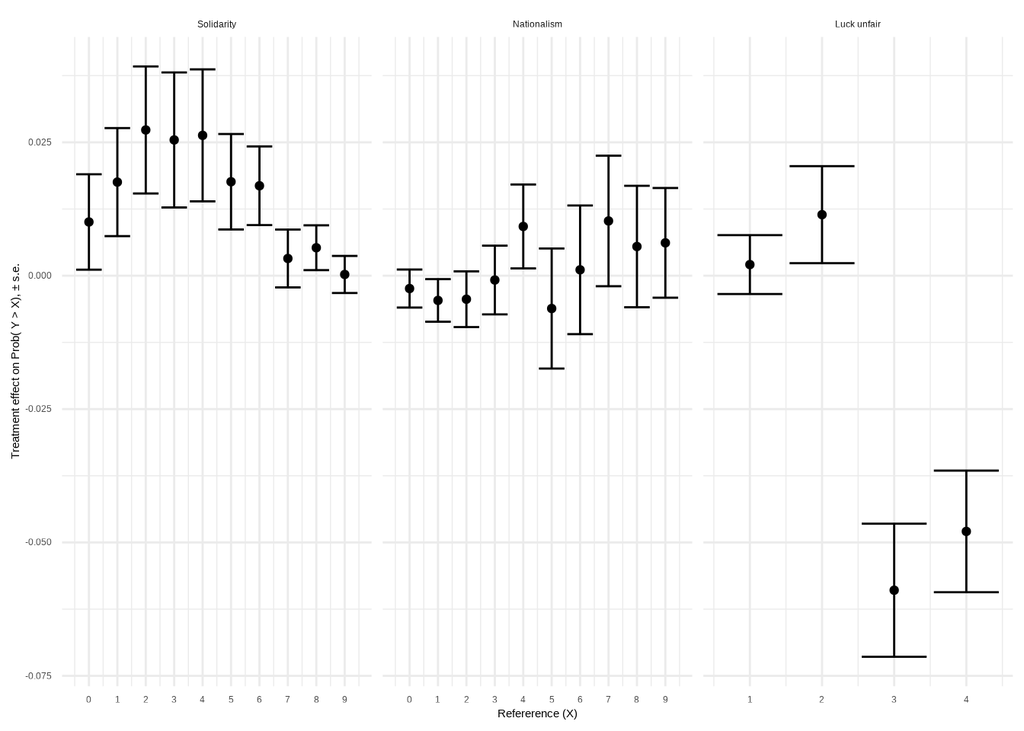

```r
distrib_effects_fig <- distrib_effects %>%
  mutate(outcomef = factor(outcome, levels=c("Solidarity", "Nationalism", "Luck unfair"))) %>%
  ggplot(aes(y=estimate,
             x=reference,
             ymin=estimate - std.error,
             ymax=estimate + std.error)) +
  geom_point() +
  geom_errorbar() +
  theme_minimal() +
  scale_x_continuous(breaks=seq(0,9,1)) +
  facet_wrap(. ~ outcomef, scales="free_x") +
  labs(y = "Treatment effect on Prob( Y > X), \u00B1 s.e.",
       x = "Refererence (X)")
distrib_effects_fig
```

```r
ggsave(here::here("graphs","distributional_effects.pdf"),
       width=16, height=10, units="cm")
```

# Treatment effects in more and less affected areas

Referee 1 suggests looking at treatment effects broken down by heterogeneity in degree of affectedness (answer to the priming questions).

> In addition, it might be possible to see whether the treatment effect tends to be stronger/weaker among individuals who (realistically) believe that the crisis will last for a long time?

and:

> One key aspect that is being discussed relatively little is whether individuals think that they might be personally affected by this crisis (that they will become sick/unemployed etc.).

We cannot look at this at the individual level, but we can ask if there treatment differences between *states* that are different in the average responses to the priming questions. We look at the heterogeneity by the objective number of confirmed cases in the state above (the `tgraphs` graph).

I create a dataset of state averages, and then define high as above median (at the state level). For the priming about number of weeks, I impute 53 weeks to those who think it will last longer than a year.

```r
state_averages <- ipsos %>% group_by(state) %>%
  summarize(mean_affected = weighted.mean(prime_affected, Weightvar, na.rm=TRUE),
            mean_weeks = weighted.mean(prime_weeks, Weightvar, na.rm=TRUE),
            confirmed_casesp = weighted.mean(confirmed_cases, Weightvar,)) %>%
  mutate(many_affected = mean_affected>median(mean_affected),
         expecting_long = mean_weeks>median(mean_weeks))
```

How correlated are these measures?

```r
with(state_averages, table(many_affected, expecting_long))
```

```
##              expecting_long
## many_affected FALSE TRUE
##         FALSE    15   11
##         TRUE     11   14
```

These are not particularly correlated measures.

Now, we can join these averages back into the ipsos dataset and look at interactions between the treatment effects and the measures of high degree of being affected.

```r
ipsos_with_avg <- ipsos %>% left_join(state_averages, by="state") %>%
  mutate( prime_expecting_long = corona_prime * expecting_long,
          prime_many_affected = corona_prime * many_affected)
```

We can run the regressions in the standard formulations as before with these interactions:

```r
severe1 <- ipsos_with_avg %>% lm( zsolidarity ~ corona_prime + prime_expecting_long + expecting_long +
                                    retirement_age + female + highinc + republican + higheduc +
                                    child + alone + urban + high_confirmed +
                                    northeast + midwest + south, data=., weights=Weightvar)
severe2 <- ipsos_with_avg %>% lm( zsolidarity ~ corona_prime + prime_many_affected + many_affected +
                                    retirement_age + female + highinc + republican + higheduc +
                                    child + alone + urban + high_confirmed +
                                    northeast + midwest + south, data=., weights=Weightvar)
severe3 <- ipsos_with_avg %>% lm( znationalism ~ corona_prime + prime_expecting_long + expecting_long +
                                    retirement_age + female + highinc + republican + higheduc +
                                    child + alone + urban + high_confirmed +
                                    northeast + midwest + south, data=., weights=Weightvar)
severe4 <- ipsos_with_avg %>% lm( znationalism ~ corona_prime + prime_many_affected + many_affected +
                                    retirement_age + female + highinc + republican + higheduc +
                                    child + alone + urban + high_confirmed +
                                    northeast + midwest + south, data=., weights=Weightvar)
severe5 <- ipsos_with_avg %>% lm( zluck_unfair ~ corona_prime + prime_expecting_long + expecting_long +
                                    retirement_age + female + highinc + republican + higheduc +
                                    child + alone + urban + high_confirmed +
                                    northeast + midwest + south, data=., weights=Weightvar)
severe6 <- ipsos_with_avg %>% lm( zluck_unfair ~ corona_prime + prime_many_affected + many_affected +
                                    retirement_age + female + highinc + republican + higheduc +
                                    child + alone + urban + high_confirmed +
                                    northeast + midwest + south, data=., weights=Weightvar)
```

We can output to a table:

```r
m_names <- c( "corona_prime" = "Treated",
             "prime_expecting_long" = "Expecting long duration X treatment",
              "prime_many_affected" = "Local community affected hard X treatment",
            "expecting_longTRUE" = "Expecting long duration",
             "many_affectedTRUE" = "Local community affected hard")
extrarows <- tribble(~v1,~v2,~v3,~v4,~v5,~v6,~v7,
                     'Other controls', 'yes','yes','yes','yes','yes','yes')
attr(extrarows, 'position') <- 11
modelsummary::modelsummary(list("(1)"=severe1,
                                "(2)"=severe2,
                                "(3)"=severe3,
                                "(4)"=severe4,
                                "(5)"=severe5,
                                "(6)"=severe6),
                           statistic = "std.error", coef_map = m_names,
                           stars = TRUE,
                           gof_omit = 'R2 Adj.|AIC|BIC|Log.Lik.|F',
                           output = 'latex',
                           add_rows = extrarows) %>%
  add_header_above(c(" " = 1, "Solidarity" = 2, "Nationalism" = 2,  "Luck unfair" = 2)) %>%
  cat(file= here::here("tables","treatment_X_outcomes.tex"))
```

## Maps of the treatment variables

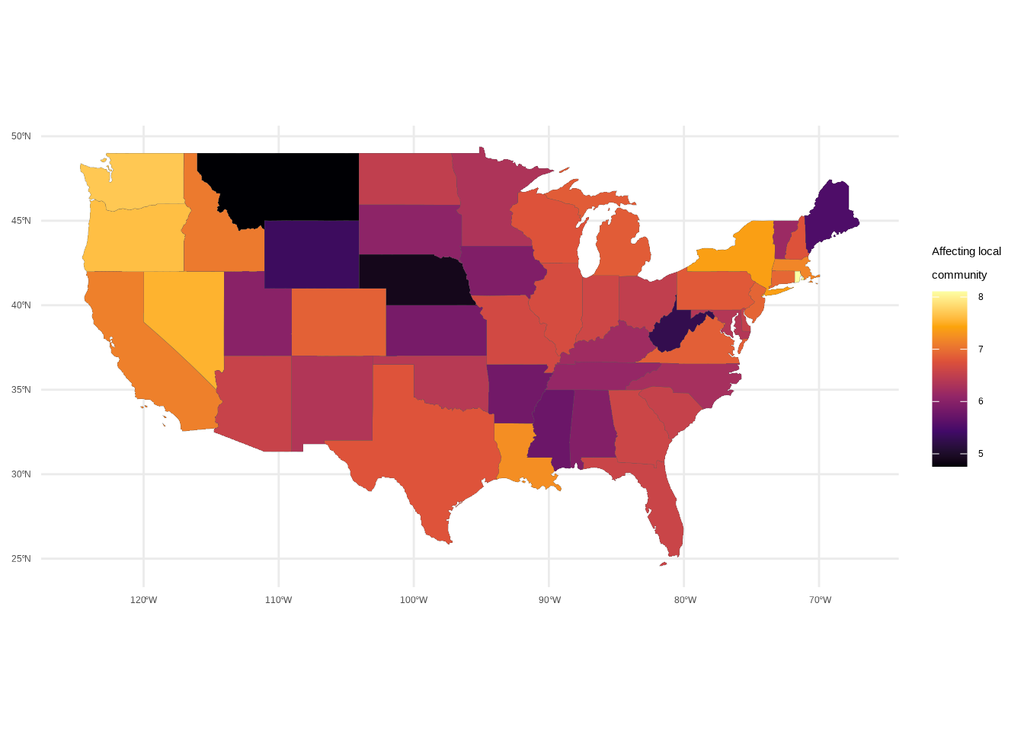

```r
us_states <- sf::st_as_sf(us_states)
state_averages_map <- us_states  %>% left_join(state_averages, by=c("NAME"="state"))
affecting <- state_averages_map %>%
  ggplot() +
  geom_sf(aes(fill=mean_affected), size=0.05) +
  theme_minimal() +
  labs(fill="Affecting local\ncommunity") +
  scale_fill_viridis_c(option = "inferno")

affecting
```

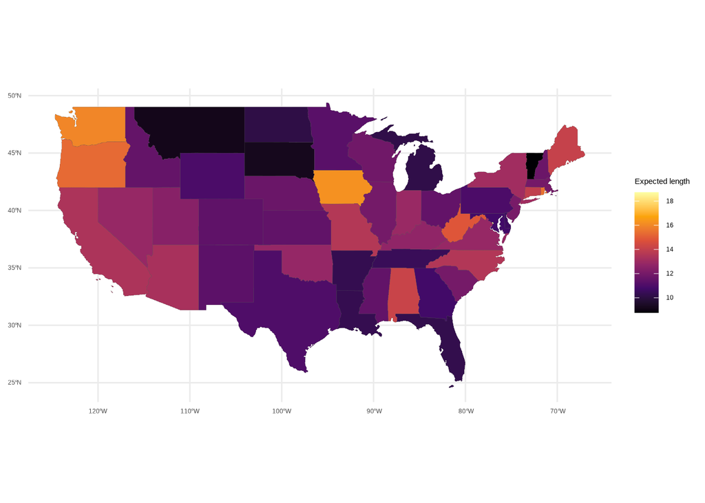

```r
ggsave(here::here("graphs","treatment_affecting_map.pdf"))
lasting <- state_averages_map %>%
  ggplot() +
  geom_sf(aes(fill=mean_weeks), size=0.05) +
  theme_minimal() +
  labs(fill="Expected length") +
  scale_fill_viridis_c(option = "inferno")

lasting
```

```r
ggsave(here::here("graphs","treatment_lasting_map.pdf"))
```